# Machine Learning Part 1: Regularization and Variable Selection in Linear Models

`PredictiveRegressions.ipynb` ended on a sobering note: a "kitchen sink" predictive regression with nine Goyal-Welch predictors fit the data well in-sample but forecast far *worse* than the simple historical average out of sample. The culprit was **overfitting** -- with many predictors and not much data, OLS fits the noise in the estimation sample along with any signal, and its forecasts swing wildly as a result. This notebook is about methods designed for exactly that situation: **regularization** (or **shrinkage**) methods, which estimate a large regression but deliberately pull the coefficients toward zero. We focus on the two most widely used ones, **ridge regression** and the **lasso**, and on **cross-validation**, the standard data-driven way to decide how hard to pull.

The notebook builds on OLS regression from `CAPM_BivariateRegression.ipynb` and `MultifactorModels_MultiVarRegression.ipynb` and on the out-of-sample (OOS) forecast evaluation in `PredictiveRegressions.ipynb`. `PCA.ipynb` introduced the machine learning vocabulary used here (features, supervised versus unsupervised learning) and covers another main approach to many predictors, dimension reduction, which we mention only briefly. We first build intuition with simulated data, where we know the true model and can check what each method gets right and wrong, and then return to the Goyal-Welch kitchen sink to see whether regularization rescues it. The optional appendix works through the one-predictor algebra behind ridge and the lasso, and then uses the matrix notation from `BasicsLinearAlgebra.ipynb`.

*Acknowledgment*: This notebook was produced with the assistance of AI. I remain responsible for the content and any errors.

## Learning Objectives

By the end of this notebook, you should be able to:

1. Explain why OLS overfits when the number of predictors is large relative to the number of observations (and breaks down entirely when it exceeds it), and describe the three main families of remedies: subset selection, regularization, and dimension reduction.
2. Explain the purpose of splitting data into training and test samples, and compute the test mean squared error (MSE) of a fitted model.
3. Define the ridge and lasso estimators as penalized least squares, explain how the penalty parameter $\lambda$ controls the amount of shrinkage, and explain why predictors should be standardized before penalizing them.
4. Explain why the lasso sets some coefficients exactly to zero while ridge does not, contrasting ridge's proportional shrinkage with the lasso's soft thresholding.
5. Estimate ridge and lasso regressions with `scikit-learn` and interpret their coefficient paths.
6. Explain $K$-fold cross-validation, use it to choose the penalty parameter, and explain why it must use only the training data (and why time series data need extra care).
7. Use a Monte Carlo simulation to compare the test MSE of OLS, ridge, and the lasso, and to measure how well the lasso picks out the truly relevant predictors.
8. Apply ridge and the lasso to out-of-sample forecasting of the equity premium, and interpret their performance relative to OLS and the historical average.
9. (Optional, appendix) Derive the ridge and lasso estimates in a regression with a single predictor and verify them numerically; write OLS and ridge regression in matrix notation, derive the ridge estimator, and explain why ridge remains well defined when OLS does not.

## Instructions to Run

**Data:** The simulation sections generate their own data. The motivating example and the final application use `data/gw_annual.csv`, the annual extract of Amit Goyal's updated Goyal and Welch (2008) predictor dataset, 1926 through 2024. It is the same file used in `PredictiveRegressions.ipynb` and is already in this repo's `data/` folder. (Where a notebook instead uses data that can't be redistributed here -- e.g. licensed WRDS data, or simply a larger extract -- the required file(s) will be posted on the course Canvas site under Data instead. Download those into your local `data/` folder before running.)

**If your data lives somewhere else:** Edit the `pd.read_csv("../data/gw_annual.csv")` line in the first code cell (the path assumes this notebook lives in `notebooks/` and `data/` is a sibling folder).

**Package dependencies:** `numpy`, `pandas`, `matplotlib`, `statsmodels`, and `scikit-learn` are all standard Anaconda packages. If you are not using Anaconda, run `pip install numpy pandas matplotlib statsmodels scikit-learn` once before running this notebook.

**Run time:** A few cells (the Monte Carlo simulation and the out-of-sample application) re-estimate models many times and take up to a minute or two each.

**Viewing the HTML export in Canvas:** If the equations below show up as raw text (things like `$\hat{\beta}^{R}$`) instead of typeset math, don't use Canvas's built-in file preview -- download the file and open it directly in your browser instead. Canvas's preview sandboxes uploaded HTML and blocks the script that typesets the math; opening the downloaded file locally has no such restriction.

## Motivating Example: The Kitchen Sink, Revisited

Recall the setup from `PredictiveRegressions.ipynb`. Each year we forecast next year's log excess return on the S&P 500 using nine predictors observed this year: the log dividend-price ratio (`dp`), corporate and government bond returns (`corpr`, `ltr`), the default yield spread (`dfy`), inflation (`infl`), the long-term bond yield (`lty`), net equity issuance (`ntis`), stock variance (`svar`), and the term spread (`tms`). Starting with 30 years of data and expanding the estimation window by one year at a time, we produce a genuine out-of-sample forecast for every year from 1958 through 2024, and compare it with the historical average return.

The code below rebuilds the data and the OOS exercise. The function `oos_forecasts` takes the model to be estimated as an argument, so that we can reuse it with ridge and the lasso at the end of the notebook. (It also standardizes the predictors within each estimation window, a step whose purpose will become clear below; it has no effect on the OLS forecasts.)

```python
import numpy as np
import pandas as pd
import matplotlib.pyplot as plt
import statsmodels.api as sm
from sklearn.base import clone
from sklearn.linear_model import LinearRegression, Ridge, RidgeCV, Lasso, LassoCV
from sklearn.model_selection import KFold, train_test_split
from sklearn.preprocessing import StandardScaler

#Annual Goyal-Welch data, 1926-2024 (see Instructions to Run). Column names follow Goyal's file
gw = pd.read_csv("../data/gw_annual.csv")
gw.index = gw['year']

data = pd.DataFrame(index=gw.index)
data['dp'] = np.log(gw['d12']) - np.log(gw['price'])     #log dividend-price ratio
data['lty'] = 100 * gw['lty']                            #long-term government bond yield (%)
data['ltr'] = 100 * gw['ltr']                            #long-term government bond return (%)
data['corpr'] = 100 * gw['corpr']                        #long-term corporate bond return (%)
data['tms'] = 100 * (gw['lty'] - gw['tbl'])              #term spread (%)
data['dfy'] = 100 * (gw['BAA'] - gw['AAA'])              #default yield spread (%)
data['infl'] = 100 * gw['infl']                          #CPI inflation (%)
data['ntis'] = 100 * gw['ntis']                          #net equity issuance (%)
data['svar'] = gw['svar']                                #stock variance
#Log excess return on the S&P 500 (including dividends) over the T-bill, in percent
data['lexret'] = (100 * (np.log(gw['price'] + gw['d12']) - np.log(gw['price'].shift(1)))
                  - 100 * np.log(1 + gw['Rfree']))
data = data.loc[1927:]

ks_predictors = ['dp', 'corpr', 'dfy', 'infl', 'ltr', 'lty', 'ntis', 'svar', 'tms']
#Row s of X_gw holds the predictors in year s; the same row of y_gw holds the return in year s+1
X_gw = data[ks_predictors].iloc[:-1]
y_gw = data['lexret'].shift(-1).iloc[:-1]


def oos_forecasts(X, y, model, n_init=30):
    #Expanding-window OOS forecasts from `model` and from the historical mean. The forecast made in
    #year t (for the return in year t+1) uses only the (predictor, return) pairs observed by year t.
    rows = []
    for t in range(n_init, len(y)):
        scaler = StandardScaler().fit(X.iloc[:t])            #standardize using past data only
        fit = clone(model).fit(scaler.transform(X.iloc[:t]), y.iloc[:t])
        rows.append({'year': X.index[t] + 1,
                     'actual': y.iloc[t],
                     'model': fit.predict(scaler.transform(X.iloc[[t]]))[0],
                     'hist_mean': y.iloc[:t].mean(),
                     'n_used': np.sum(fit.coef_ != 0)})          #number of predictors with nonzero slopes
    return pd.DataFrame(rows).set_index('year')


def r2_oos(oos, col='model'):
    msfe = ((oos['actual'] - oos[col])**2).mean()
    msfe_bmk = ((oos['actual'] - oos['hist_mean'])**2).mean()
    return 1 - msfe / msfe_bmk


oos_ols = oos_forecasts(X_gw, y_gw, LinearRegression())
print(f"OOS period: {oos_ols.index[0]} to {oos_ols.index[-1]} ({len(oos_ols)} years)")
print(f"Out-of-sample R-squared, kitchen sink OLS vs. historical average: {100 * r2_oos(oos_ols):.1f}%")
```

```
OOS period: 1958 to 2024 (67 years)
Out-of-sample R-squared, kitchen sink OLS vs. historical average: -64.3%
```

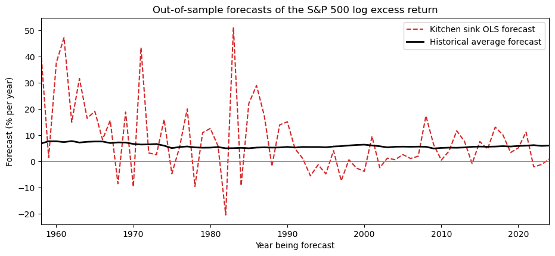

```python
fig, ax = plt.subplots(figsize=(11, 4.5))
ax.plot(oos_ols.index, oos_ols['model'], color='tab:red', linestyle='--', linewidth=1.5,
        label='Kitchen sink OLS forecast')
ax.plot(oos_ols.index, oos_ols['hist_mean'], color='black', linewidth=2, label='Historical average forecast')
ax.axhline(0, color='gray', linewidth=0.8)
ax.set_title("Out-of-sample forecasts of the S&P 500 log excess return")
ax.set_xlabel("Year being forecast")
ax.set_ylabel("Forecast (% per year)")
ax.set_xlim(oos_ols.index.min(), oos_ols.index.max())
ax.legend()
plt.show()
```

The out-of-sample $R^2$ is hugely negative: the kitchen sink model's mean squared forecast error is well above that of the historical average. The plot shows why. The OLS forecasts (dashed red) jump around from year to year by tens of percentage points, while the historical average (solid black) barely moves. With nine slopes estimated from as few as 30 observations, the coefficient estimates are very noisy, and that noise passes straight through to the forecasts.

Notice what the historical average is: it is the forecast from the same regression with *every slope set to zero*. So we have two extremes. One uses all nine predictors with their noisy OLS slopes; the other ignores the predictors entirely. Is there something in between -- a way to use the predictors, but with slopes pulled toward zero so the forecasts don't swing so violently? That is exactly what regularization does. We develop the ideas with simulated data, where we know the truth, and return to this example at the end.

## The Problem: Many Predictors

Suppose we want to predict an outcome $Y$ using $p$ candidate predictors (or "features") $X_1, \dots, X_p$, and we have $N$ observations, which could be cross-sectional or over time. We stick with standard linear models:

$$ Y_i = \beta_0 + \beta_1 X_{i,1} + \beta_2 X_{i,2} + \cdots + \beta_p X_{i,p} + \epsilon_i, \qquad E(\epsilon_i \mid X_{i,1}, \dots, X_{i,p}) = 0, $$

so that $\beta_0 + \sum_{j=1}^p \beta_j X_{i,j}$ is the conditional expectation of $Y_i$ given the predictors. Things might seem straightforward: estimate the $\beta$s by OLS and use the estimates to compute predictions for new values of the predictors.

*So what's the problem?* In many applications $p$ is large. Theory can only take us so far, and there are often many variables that might contain relevant information about $Y$. Large $p$ causes two problems:

1. **If $p + 1 > N$, OLS breaks down.** We have more coefficients to estimate than observations, so there are infinitely many combinations of coefficients that fit the sample data *perfectly*, and no unique OLS estimate. (Think of fitting a line, $p = 1$, through a single data point: any line through that point fits perfectly.) The appendix states this precisely in matrix notation.
2. **Even if $p + 1 < N$, OLS overfits when $p$ is large relative to $N$.** Suppose $N = 100$ and $p = 50$: we have only two observations per coefficient. The OLS estimates exist, but they are very imprecise, and OLS will happily use the irrelevant predictors (those whose true slope is zero) to fit noise in the sample. The fit looks great in-sample and poor out of sample -- the kitchen sink above, with $p = 9$ and $N$ as small as 30, is an example.

### Three general directions

Because high-dimensional regression problems are so common, there has been a great deal of work on them. Three general directions:

1. **Subset selection**: Evaluate alternative candidate models, each using a subset of the predictors, and choose the best one (or at least a good one). With $p$ predictors there are $2^p$ possible subsets -- over a quadrillion for $p = 50$ -- so in practice these methods search "forward" (adding variables one at a time) or "backward" (dropping them one at a time).
2. **Dimension reduction**: Replace the $p$ predictors with a much smaller number $K \ll p$ of combinations of them, and run an ordinary regression on those. The prototypical example is *principal components regression*, which uses the first few principal components from `PCA.ipynb` as the predictors. Because we covered PCA in the previous notebook, we do not pursue this approach further here.
3. **Regularization (shrinkage)**: Estimate the full model with all $p$ predictors, but constrain or shrink the estimated coefficients toward zero. Shrinking can substantially reduce the variance of the predictions. The cost is some bias (the true coefficients are not all zero), but the **bias-variance tradeoff** often favors shrinking, in the sense that predictions become more accurate on average.

This notebook focuses on the third direction. As we will see, one regularization method, the lasso, also performs a form of subset selection along the way.

## A Simulated Example

To see clearly what each method does, we use simulated data where we know the true model. There are $p = 50$ predictors, each an independent standard normal random variable, and $N = 200$ observations. Only the first six predictors matter:

$$ Y_i = 3X_{i,1} + 2X_{i,2} + X_{i,3} - X_{i,4} - 2X_{i,5} - 3X_{i,6} + \epsilon_i, \qquad \epsilon_i \sim N(0, 7^2). $$

The other 44 predictors have true slopes of zero. The noise is large: the standard deviation of the "signal" $\sum_j \beta_j X_{i,j}$ is $\sqrt{9+4+1+1+4+9} = \sqrt{28} \approx 5.3$, smaller than the noise standard deviation of 7. Even the true model leaves much of the variation in $Y$ unexplained, as in most finance applications.

```python
p, N, sigma = 50, 200, 7
beta_true = np.zeros(p)
beta_true[:6] = [3, 2, 1, -1, -2, -3]     #predictors 0-5 matter; 6-49 are irrelevant
cols = [f'x{j}' for j in range(p)]        #Python counts from zero, so the relevant ones are x0-x5


def draw_data(rng):
    #One simulated dataset: N draws of the p independent standard normal predictors, and Y
    X = rng.standard_normal((N, p))
    Y = X @ beta_true + sigma * rng.standard_normal(N)
    return pd.DataFrame(X, columns=cols), pd.Series(Y, name='Y')


rng = np.random.default_rng(4414)
X, Y = draw_data(rng)
print(f"Std. dev. of the signal in this sample: {np.std(X @ beta_true):.2f}  (noise std. dev. = {sigma})")
X.iloc[:5, :8].round(3)
```

```
Std. dev. of the signal in this sample: 5.48  (noise std. dev. = 7)
```

|  | x0 | x1 | x2 | x3 | x4 | x5 | x6 | x7 |
| --- | --- | --- | --- | --- | --- | --- | --- | --- |
| 0 | 0.995 | -1.370 | 0.090 | 0.110 | -0.398 | -1.027 | -1.493 | -0.942 |
| 1 | 0.278 | 0.511 | -0.959 | 1.119 | 1.362 | -1.077 | 0.210 | -1.310 |
| 2 | 1.076 | -0.343 | 0.759 | -0.321 | -1.427 | 1.345 | 1.270 | 1.028 |
| 3 | -2.439 | -0.080 | 0.533 | 0.113 | -0.911 | 0.215 | -2.775 | 0.534 |
| 4 | 0.423 | -0.542 | -0.933 | -2.188 | -0.871 | 1.163 | -1.037 | 0.509 |

### Training versus test samples

We now split the dataset into two equal halves: a **training sample** and a **test sample** (also called a "holdout" sample). This is standard practice in machine learning. All estimation -- including any choice of tuning parameters -- uses only the training sample. We then apply the fitted model to the test sample and measure performance there, typically by the **test mean squared error**,

$$ \text{Test MSE} = \frac{1}{N_{test}} \sum_{i \in \text{test}} \left(Y_i - \hat{Y}_i\right)^2, $$

where $\hat{Y}_i$ is the model's prediction for observation $i$. Because the test data played no role in fitting the model, the test MSE is an honest measure of how well the model predicts new data. The in-sample (training) fit is not: a model that has fit the noise in the training sample will look better there than it really is.

(`train_test_split` assigns observations to the two samples at random, scrambling their order. That is fine here because our simulated observations are independent, but it is a problem for time series, where we must not use the future to predict the past -- which is why the OOS exercise in the motivating example instead estimates on earlier years and forecasts later ones.)

```python
X_train, X_test, Y_train, Y_test = train_test_split(X, Y, test_size=0.5, random_state=1)


def test_mse(model):
    return np.mean((Y_test - model.predict(X_test))**2)


#Two benchmarks: the training-sample mean of Y (ignore all predictors), and the true model
mse_mean = np.mean((Y_test - Y_train.mean())**2)
mse_true = np.mean((Y_test - X_test @ beta_true)**2)
print(f"Training / test observations: {len(Y_train)} / {len(Y_test)}")
print(f"Test MSE, predicting with the training-sample mean: {mse_mean:6.1f}")
print(f"Test MSE, using the TRUE coefficients:              {mse_true:6.1f}  (population value: sigma^2 = {sigma**2})")
```

```
Training / test observations: 100 / 100
Test MSE, predicting with the training-sample mean:   61.9
Test MSE, using the TRUE coefficients:                41.5  (population value: sigma^2 = 49)
```

These two numbers bracket what we can hope for. Even knowing the true coefficients, the test MSE is around $\sigma^2 = 49$, because the noise $\epsilon_i$ cannot be predicted. Ignoring the predictors and predicting with the sample mean does noticeably worse. A good estimation method should land somewhere between the two -- and, ideally, close to the true model.

### OLS with all 50 predictors

First, the "kitchen sink": OLS on all 50 predictors, using the 100 training observations.

```python
ols_sm = sm.OLS(Y_train, sm.add_constant(X_train)).fit()
pvals = ols_sm.pvalues.drop('const')
ols = LinearRegression().fit(X_train, Y_train)     #the same OLS fit, in scikit-learn form

print(f"In-sample R-squared:          {ols_sm.rsquared:.3f}")
print(f"In-sample adjusted R-squared: {ols_sm.rsquared_adj:.3f}")
print(f"Irrelevant predictors (true slope 0) 'significant' at 5%: {(pvals[cols[6:]] < 0.05).sum()} of 44")
print(f"Training MSE: {np.mean(ols_sm.resid**2):6.1f}")
print(f"Test MSE:     {test_mse(ols):6.1f}")
```

```
In-sample R-squared:          0.591
In-sample adjusted R-squared: 0.174
Irrelevant predictors (true slope 0) 'significant' at 5%: 1 of 44
Training MSE:   31.4
Test MSE:      101.4
```

OLS looks impressive in-sample. Its $R^2$ is well above what even the true model could deliver: in population, the true model's $R^2$ is the signal variance over the total variance, $28/(28 + 49) \approx 0.36$. The adjusted $R^2$ is much lower, a hint that something is off. (With 44 irrelevant predictors and a 5% significance level we would also expect about two of them to look "significant" by chance alone; in this sample, only about that many do, so the $t$-statistics are not where the damage shows up.) The test MSE tells the real story. The training MSE is far *below* $\sigma^2 = 49$ (OLS has fit much of the noise), while the test MSE is far *above* it, and worse than simply predicting with the sample mean. This is overfitting in its purest form.

## Ridge Regression

Recall that OLS chooses the coefficients to minimize the **residual sum of squares** (RSS):

$$ \text{RSS} = \sum_{i=1}^{N} \left(Y_{i} - \beta_{0} - \sum_{j=1}^{p} \beta_{j} X_{i,j}\right)^{2}. $$

**Ridge regression** chooses the coefficients in almost the same way, with one important modification. The ridge coefficients $\hat{\beta}^{R}$ minimize

$$ \sum_{i=1}^{N} \left(Y_{i} - \beta_{0} - \sum_{j=1}^{p} \beta_{j} X_{i,j}\right)^{2} + \lambda \sum_{j=1}^{p} \beta^{2}_{j} \;=\; \text{RSS} + \lambda \sum_{j=1}^{p} \beta^{2}_{j}, $$

where $\lambda \ge 0$ is a separately chosen **penalty parameter** (or *tuning parameter*). In words: ridge looks for coefficients that fit the data well, as OLS does, but it charges a price for large coefficients, and the price per unit of squared coefficient is $\lambda$. Adding a penalty term like this to the RSS is called **penalized regression**. Note that the intercept $\beta_0$ is not penalized -- we want to shrink the *slopes* toward zero, not the overall level of the predictions.

Intuitively, the penalty "shrinks" the slope coefficients toward zero: a large slope must buy enough improvement in fit to justify its cost. The larger $\lambda$, the higher the price and the more shrinkage. Extremes help with intuition:

1. $\lambda \rightarrow 0$: The penalty disappears, and ridge becomes OLS again.
2. $\lambda \rightarrow \infty$: The penalty dominates, so all the slopes are driven to zero. Only the unpenalized intercept is left, and the prediction becomes the sample mean of $Y$ -- the historical average of the motivating example.

Ridge regression lets us move smoothly between these two extremes. As $\lambda$ grows, the forecasts become less volatile (lower variance), at the cost of being pulled further from the true coefficients (more bias). The elephant in the room is *how to choose $\lambda$*; we come back to that below, under cross-validation.

One final point to file away: ridge shrinks every slope toward zero, but in general it does not set any of them *exactly* to zero. A ridge regression with 50 predictors still uses all 50. It does not perform variable selection.

## The Lasso

The **lasso** ("least absolute shrinkage and selection operator") is another penalized regression. Its coefficients $\hat{\beta}^{L}$ minimize

$$ \sum_{i=1}^{N} \left(Y_{i} - \beta_{0} - \sum_{j=1}^{p} \beta_{j} X_{i,j}\right)^{2} + \lambda \sum_{j=1}^{p} |\beta_{j}| \;=\; \text{RSS} + \lambda \sum_{j=1}^{p} |\beta_{j}|. $$

The only difference from ridge is how the size of the coefficients is measured: by the sum of their *absolute values* rather than the sum of their *squares*.

1. Ridge regression measures coefficient size by the sum of squares, the square of the ordinary (Euclidean) length of the coefficient vector, known as the $\ell_{2}$ norm. Ridge is therefore called $\ell_{2}$ regularization.
2. The lasso measures coefficient size by the sum of absolute values, known as the $\ell_{1}$ norm (or "Manhattan distance," the distance you travel between two points on a city grid). The lasso is $\ell_{1}$ regularization.

That might sound like a technicality, but it has an important consequence. Like ridge, the lasso shrinks coefficients toward zero, more so for larger $\lambda$. But the $\ell_{1}$ penalty also *forces some coefficients to be exactly zero* when $\lambda$ is large enough. So the lasso performs variable selection: it produces **sparse** models, which involve only a subset of the predictors. Sparse models are also much easier to interpret than ridge models that give every predictor a nonzero weight.

### Why the lasso produces exact zeros

The cleanest way to see the difference between ridge and the lasso is a regression with a single predictor, where both estimators can be worked out by hand. The appendix does the algebra; here are the results.

- **Ridge shrinks proportionally.** It multiplies the OLS estimate by a shrinkage factor between zero and one. The factor is one when $\lambda = 0$ and falls toward zero as $\lambda$ grows, but it never reaches zero for any finite $\lambda$. A big OLS coefficient and a small one are shrunk by the same percentage, and neither becomes exactly zero.
- **The lasso soft-thresholds.** It subtracts a fixed amount, which grows with $\lambda$, from the size of the OLS estimate -- and if the OLS estimate is smaller than that amount to begin with, it sets the coefficient to exactly zero. This is called **soft thresholding**. Small, probably-noise coefficients are eliminated, while large coefficients survive, shrunk toward zero.

The intuition for the difference lies in the shape of the penalties near zero. The ridge penalty $\lambda\beta^2$ is flat at zero: its marginal cost, $2\lambda\beta$, vanishes as $\beta$ approaches zero, so it always pays to keep a little bit of any predictor that helps the fit at all. The lasso penalty $\lambda|\beta|$ has a marginal cost of $\lambda$ no matter how close to zero $\beta$ is, so a predictor has to improve the fit by at least that much to earn a nonzero coefficient.

With many predictors that are correlated with one another, the estimates are more complicated and there is no closed form for the lasso, but the same logic applies to each coefficient. The plot below shows the two rules side by side.

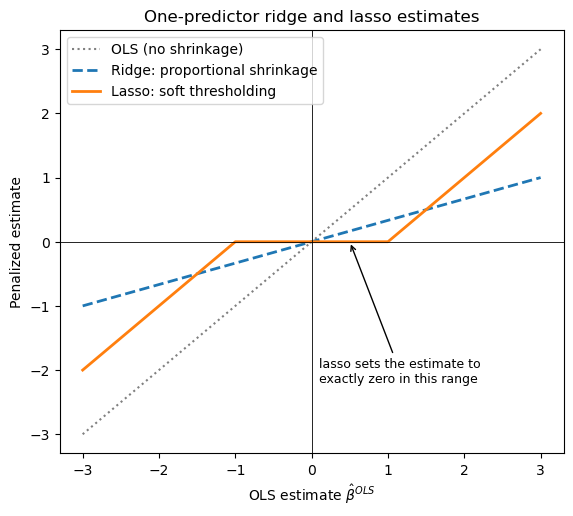

```python
b_ols = np.linspace(-3, 3, 601)
S_xx, lam = 1.0, 2.0                      #units chosen so that the lasso threshold c = lam/(2 S_xx) = 1
b_ridge = b_ols * S_xx / (S_xx + lam)
b_lasso = np.sign(b_ols) * np.maximum(np.abs(b_ols) - lam / (2 * S_xx), 0)

fig, ax = plt.subplots(figsize=(6.5, 5.5))
ax.plot(b_ols, b_ols, color='gray', linestyle=':', linewidth=1.5, label='OLS (no shrinkage)')
ax.plot(b_ols, b_ridge, color='tab:blue', linestyle='--', linewidth=2, label='Ridge: proportional shrinkage')
ax.plot(b_ols, b_lasso, color='tab:orange', linewidth=2, label='Lasso: soft thresholding')
ax.axhline(0, color='black', linewidth=0.6)
ax.axvline(0, color='black', linewidth=0.6)
ax.annotate('lasso sets the estimate to\nexactly zero in this range', xy=(0.5, 0), xytext=(0.1, -2.2),
            arrowprops=dict(arrowstyle='->', color='black'), fontsize=9)
ax.set_xlabel(r"OLS estimate $\hat{\beta}^{OLS}$")
ax.set_ylabel("Penalized estimate")
ax.set_title("One-predictor ridge and lasso estimates")
ax.legend(loc='upper left')
plt.show()
```

**A note on `scikit-learn`'s penalty parameter.** `scikit-learn` calls the penalty parameter `alpha` rather than $\lambda$, and it scales the two criteria differently. `Ridge(alpha=a)` minimizes $\text{RSS} + a\sum_j\beta_j^2$, so its `alpha` is our $\lambda$. But `Lasso(alpha=a)` minimizes $\frac{1}{2N}\text{RSS} + a\sum_j|\beta_j|$. Multiplying that criterion by $2N$ (which doesn't change where its minimum is) gives $\text{RSS} + 2Na\sum_j|\beta_j|$, so the lasso's `alpha` corresponds to $\lambda = 2N \times$ `alpha`. In the rest of the notebook we work directly with `scikit-learn`'s `alpha`, but keep in mind that the numbers are not comparable between ridge and the lasso.

### Standardize the predictors first

The penalty treats every coefficient the same way, but the size of a coefficient depends on the units of its predictor. Measure a predictor in percent rather than in decimals and its OLS coefficient becomes 100 times smaller, so it is penalized much less -- even though nothing about its information content has changed. To put all predictors on an equal footing, the standard practice is to **standardize** each predictor (subtract its mean and divide by its standard deviation) before running ridge or the lasso. This is the same issue that came up in `PCA.ipynb`, where results also depend on the units of the variables. Our simulated predictors are already standard normal, so we can skip this step for now; in the Goyal-Welch application, whose predictors come in very different units, `oos_forecasts` standardizes them, using only the data in each estimation window.

## Applying Ridge Regression

Back to the 50-predictor simulated data. The plot below shows the **coefficient path**: the ridge estimates of all 50 slopes, estimated on the training sample, for a range of values of `alpha` (our $\lambda$) from 0.01 to 100,000, on a log scale. The six truly relevant predictors are drawn in color; the 44 irrelevant ones in thin gray.

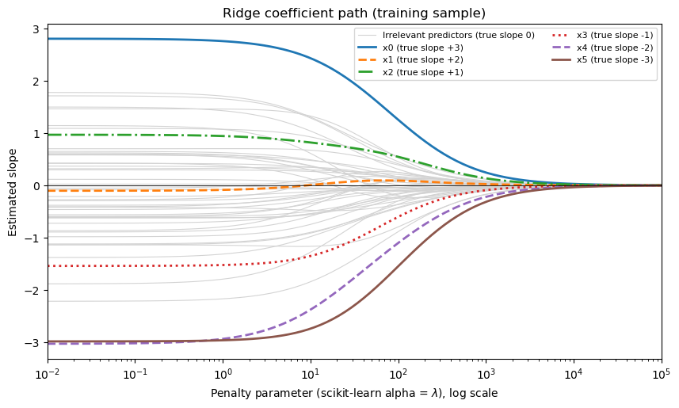

```python
ridge_alphas = np.logspace(-2, 5, 100)
ridge_path = np.array([Ridge(alpha=a).fit(X_train, Y_train).coef_ for a in ridge_alphas])

true_colors = ['tab:blue', 'tab:orange', 'tab:green', 'tab:red', 'tab:purple', 'tab:brown']
true_styles = ['-', '--', '-.', ':', '--', '-']


def plot_path(alphas, path, title, xlabel):
    fig, ax = plt.subplots(figsize=(10, 5.5))
    for j in range(6, p):
        ax.plot(alphas, path[:, j], color='lightgray', linewidth=0.8,
                label='Irrelevant predictors (true slope 0)' if j == 6 else None)
    for j in range(6):
        ax.plot(alphas, path[:, j], color=true_colors[j], linestyle=true_styles[j], linewidth=2,
                label=f'x{j} (true slope {beta_true[j]:+.0f})')
    ax.axhline(0, color='black', linewidth=0.6)
    ax.set_xscale('log')
    ax.set_xlim(alphas.min(), alphas.max())
    ax.set_xlabel(xlabel)
    ax.set_ylabel('Estimated slope')
    ax.set_title(title)
    ax.legend(loc='upper right', fontsize=8, ncol=2)
    plt.show()


plot_path(ridge_alphas, ridge_path, 'Ridge coefficient path (training sample)',
          r'Penalty parameter (scikit-learn alpha = $\lambda$), log scale')
```

At the far left the penalty is negligible and the estimates are the OLS estimates. Most of the relevant predictors' estimates are in the right neighborhood, but many of the irrelevant predictors have sizable estimates too -- that is the overfitting. (One relevant predictor, `x1`, has an estimate near zero despite its true slope of +2. That is just sampling noise in this particular training sample, a reminder that with noisy data even a real effect can be hidden.) As the penalty increases, all of the coefficients shrink smoothly toward zero, and at the far right they are all essentially zero, so that the prediction is just the mean of $Y$. Consistent with the one-predictor analysis, no coefficient drops out early: they all shrink together.

How does ridge predict? The cell below computes the test MSE for a few values of the penalty, from zero (which is OLS) to a very large value.

```python
print(f"{'alpha':>9} | {'test MSE':>8} | {'avg |slope|, x0-x5':>18} | {'avg |slope|, x6-x49':>19}")
for a in [0, 1, 10, 100, 1000, 100000]:
    ridge_a = Ridge(alpha=a).fit(X_train, Y_train)
    print(f"{a:>9} | {test_mse(ridge_a):8.1f} | {np.abs(ridge_a.coef_[:6]).mean():18.3f} | "
          f"{np.abs(ridge_a.coef_[6:]).mean():19.3f}")
print(f"\nBenchmarks: training-sample mean {mse_mean:.1f}, true model {mse_true:.1f}")
```

```
    alpha | test MSE | avg |slope|, x0-x5 | avg |slope|, x6-x49
        0 |    101.4 |              1.906 |               0.735
        1 |     97.1 |              1.870 |               0.707
       10 |     75.1 |              1.622 |               0.544
      100 |     52.1 |              0.857 |               0.235
     1000 |     58.3 |              0.172 |               0.052
   100000 |     61.8 |              0.002 |               0.001

Benchmarks: training-sample mean 61.9, true model 41.5
```

With no penalty we have OLS and its poor test MSE. As the penalty rises, the irrelevant coefficients shrink (that is the variance reduction) and the test MSE improves substantially. Push the penalty too far, though, and the *relevant* coefficients are shrunk away too (that is the bias), until at the largest value the test MSE is essentially that of the sample mean. The best value of $\lambda$ is somewhere in the middle: a "Goldilocks" penalty.

## Applying the Lasso

Now the same exercise with the lasso. Remember that `scikit-learn`'s lasso `alpha` is scaled differently (it equals $\lambda / 2N$), so the range of values on the horizontal axis is not comparable with the ridge plot.

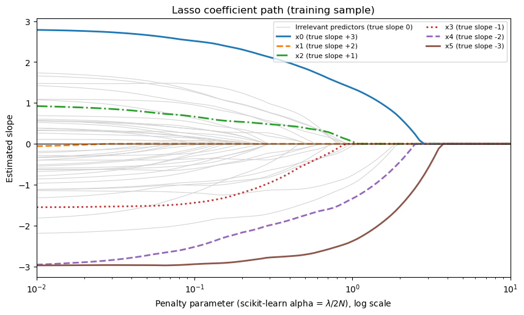

```python
lasso_alphas = np.logspace(-2, 1, 100)
lasso_path = np.array([Lasso(alpha=a, max_iter=10000).fit(X_train, Y_train).coef_ for a in lasso_alphas])
plot_path(lasso_alphas, lasso_path, 'Lasso coefficient path (training sample)',
          r'Penalty parameter (scikit-learn alpha = $\lambda / 2N$), log scale')
```

The difference from ridge is striking. As the penalty rises, coefficients don't just shrink -- they hit zero and stay there, one after another. Nearly all of the irrelevant predictors are eliminated by the time the penalty reaches about 1, while the predictors with the largest estimated slopes -- here `x0`, `x4`, and `x5`, with true slopes of $+3$, $-2$, and $-3$ -- survive the longest. The lasso is doing variable selection. It can only select based on what the data show, though: `x1`, a genuinely relevant predictor whose estimate happens to be near zero in this sample, is among the first to go.

As with ridge, let's look at the test MSE and the number of predictors the lasso keeps for a few values of the penalty.

```python
print(f"{'alpha':>6} | {'test MSE':>8} | {'# nonzero slopes':>16} | {'# of x0-x5 kept':>15} | {'# of x6-x49 kept':>16}")
for a in [0.1, 0.5, 1, 2, 3]:
    lasso_a = Lasso(alpha=a, max_iter=10000).fit(X_train, Y_train)
    nz = lasso_a.coef_ != 0
    print(f"{a:>6} | {test_mse(lasso_a):8.1f} | {nz.sum():16d} | {nz[:6].sum():15d} | {nz[6:].sum():16d}")
print(f"\nBenchmarks: training-sample mean {mse_mean:.1f}, true model {mse_true:.1f}")
```

```
 alpha | test MSE | # nonzero slopes | # of x0-x5 kept | # of x6-x49 kept
   0.1 |     74.2 |               42 |               5 |               37
   0.5 |     54.8 |               20 |               5 |               15
     1 |     52.4 |                7 |               4 |                3
     2 |     53.1 |                3 |               3 |                0
     3 |     59.4 |                1 |               1 |                0

Benchmarks: training-sample mean 61.9, true model 41.5
```

The same tradeoff appears. A small penalty keeps many irrelevant predictors and predicts relatively poorly. A moderate penalty removes most of them and improves the test MSE. A large penalty removes the relevant predictors as well -- at the largest value shown, only one predictor survives, and the test MSE is heading back up toward that of the sample mean. Again, we need a Goldilocks penalty.

## Choosing the Penalty: Cross-Validation

The behavior of ridge and the lasso depends critically on $\lambda$. Too large, and the model effectively ignores the predictors (the sample mean). Too small, and we are back to OLS, which does poorly when $p$ is large relative to $N$. How do we find the value in between?

We just *looked at the test MSE* for several values -- but we can't choose $\lambda$ that way. The test sample is supposed to measure how the final model does on genuinely new data; if we use it to choose $\lambda$, it is no longer new, and the test MSE of the chosen model is biased downward. In a real application there is no test sample to peek at anyway: the future hasn't happened yet. We need a way to choose $\lambda$ using **only the training data**. The standard approach is **cross-validation** (CV): we mimic the training/test split *within* the training sample.

In classic **leave-one-out cross-validation**, we:

1. Set aside the first observation.
2. Estimate the model (lasso, ridge, or any other model that requires a tuning parameter) on the remaining $N-1$ observations, once for each candidate value of the tuning parameter.
3. Use these estimates to predict the held-out first observation, giving one prediction for each candidate value.
4. Compute the squared prediction error for the held-out observation, again one for each candidate value.
5. Repeat steps 1-4, holding out the second, third, ..., $N$-th observation in turn.
6. For each candidate value, average the squared prediction errors across all $N$ held-out observations. This is the cross-validated MSE.

We then choose the tuning parameter value with the smallest cross-validated MSE.

A variation that often performs better (and is much cheaper to compute) is **$K$-fold cross-validation**. We randomly divide the training data into $K$ groups, or *folds*, of roughly equal size -- for 10-fold CV, ten "bins." The first fold is held out as a validation set and the model is fit on the remaining $K-1$ folds, for each candidate value of $\lambda$. We compute the MSE on the held-out fold. We repeat this $K$ times, so that each fold is held out once, average the $K$ MSEs, and choose the $\lambda$ that minimizes the average. (Leave-one-out CV is the special case $K = N$.)

*It is critical that the CV analysis be done on the training sample, and in particular **not** on the test sample.*

For time series, the random assignment of observations to folds raises the same concern as the random training/test split: the model may be estimated with future data and evaluated on the past. A common compromise, which we use in the Goyal-Welch application, is to make each fold a *contiguous block* of time rather than a random set of observations. For a more detailed treatment of cross-validation, see Chapter 5 of the *Introduction to Statistical Learning* book posted on Canvas (Chapter 6 covers ridge and the lasso).

### Cross-validation in `scikit-learn`

`RidgeCV` and `LassoCV` do all of this automatically. By default `RidgeCV` uses leave-one-out CV, which for ridge regression can be computed very efficiently without actually re-estimating the model $N$ times. For the lasso we use 10-fold CV. `LassoCV` chooses its own grid of candidate penalties, starting from the smallest value at which all coefficients are zero.

```python
ridgecv = RidgeCV(alphas=ridge_alphas).fit(X_train, Y_train)      #leave-one-out CV
lassocv = LassoCV(cv=KFold(10, shuffle=True, random_state=0), max_iter=10000).fit(X_train, Y_train)

print(f"Ridge: CV-chosen alpha = {ridgecv.alpha_:8.2f}, test MSE = {test_mse(ridgecv):5.1f}")
print(f"Lasso: CV-chosen alpha = {lassocv.alpha_:8.2f}, test MSE = {test_mse(lassocv):5.1f}, "
      f"nonzero slopes = {(lassocv.coef_ != 0).sum()}")
print("\nPredictors kept by the CV-chosen lasso, with their estimated slopes:")
print(pd.Series(lassocv.coef_, index=cols)[lassocv.coef_ != 0].round(2).to_string())
```

```
Ridge: CV-chosen alpha =   242.01, test MSE =  53.4
Lasso: CV-chosen alpha =     1.11, test MSE =  52.0, nonzero slopes = 5

Predictors kept by the CV-chosen lasso, with their estimated slopes:
x0     1.28
x4    -1.24
x5    -2.29
x8    -0.66
x33   -0.87
```

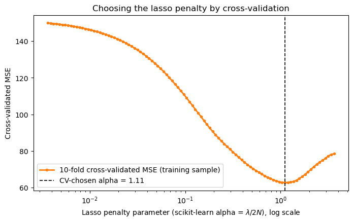

```python
cv_mse = lassocv.mse_path_.mean(axis=1)        #average MSE across the 10 folds, for each candidate alpha
fig, ax = plt.subplots(figsize=(8, 4.5))
ax.plot(lassocv.alphas_, cv_mse, color='tab:orange', linewidth=2, marker='o', markersize=3,
        label='10-fold cross-validated MSE (training sample)')
ax.axvline(lassocv.alpha_, color='black', linestyle='--', linewidth=1.2,
           label=f'CV-chosen alpha = {lassocv.alpha_:.2f}')
ax.set_xscale('log')
ax.set_xlabel(r'Lasso penalty parameter (scikit-learn alpha = $\lambda / 2N$), log scale')
ax.set_ylabel('Cross-validated MSE')
ax.set_title('Choosing the lasso penalty by cross-validation')
ax.legend()
plt.show()
```

The cross-validated MSE traces out exactly the U-shape we saw informally with the test MSE: high at small penalties (overfitting), high at large penalties (too much shrinkage), and lowest in between. CV picks the bottom of the U, using only the training data.

Here is a summary of the test MSEs on our single simulated dataset:

```python
summary = pd.Series({'OLS, all 50 predictors': test_mse(ols),
                     'Ridge, CV-chosen penalty': test_mse(ridgecv),
                     'Lasso, CV-chosen penalty': test_mse(lassocv),
                     'Training-sample mean (no predictors)': mse_mean,
                     'True coefficients (infeasible)': mse_true}, name='Test MSE')
summary.round(1).to_frame()
```

|  | Test MSE |
| --- | --- |
| OLS, all 50 predictors | 101.4 |
| Ridge, CV-chosen penalty | 53.4 |
| Lasso, CV-chosen penalty | 52.0 |
| Training-sample mean (no predictors) | 61.9 |
| True coefficients (infeasible) | 41.5 |

Both regularized models beat OLS by a wide margin and also beat the sample mean, closing much of the gap between the sample mean and the infeasible true model. In this example the lasso keeps just five predictors: three of the six relevant ones (missing `x1` and the two weakest, with true slopes of $\pm 1$) and two irrelevant ones with fairly small coefficients. Ridge keeps all 50, but with shrunken coefficients.

But this is just one simulated dataset, and one random training/test split. Is the ranking a fluke?

## Monte Carlo: How Reliable Are These Results?

To find out, we repeat the whole exercise on 200 independent simulated datasets, each drawn from the same true model. For each one, we estimate OLS, ridge, and the lasso on the first 100 observations (choosing the penalties by CV within those 100) and compute the test MSE on the other 100. We also record which predictors the lasso keeps. Because the simulated observations are independent, using the first and last 100 as the training and test samples is just as good as a random split.

```python
n_sims = 200
rng_mc = np.random.default_rng(2026)
mc_mse, mc_selected = [], []
for s in range(n_sims):
    Xs, Ys = draw_data(rng_mc)
    Xtr, Xte, Ytr, Yte = Xs.iloc[:100], Xs.iloc[100:], Ys.iloc[:100], Ys.iloc[100:]
    fits = {'OLS': LinearRegression().fit(Xtr, Ytr),
            'Ridge (CV)': RidgeCV(alphas=ridge_alphas).fit(Xtr, Ytr),
            'Lasso (CV)': LassoCV(cv=KFold(10, shuffle=True, random_state=s), max_iter=10000).fit(Xtr, Ytr)}
    row = {name: np.mean((Yte - m.predict(Xte))**2) for name, m in fits.items()}
    row['Sample mean'] = np.mean((Yte - Ytr.mean())**2)
    row['True model'] = np.mean((Yte - Xte @ beta_true)**2)
    mc_mse.append(row)
    mc_selected.append(fits['Lasso (CV)'].coef_ != 0)
mc_mse, mc_selected = pd.DataFrame(mc_mse), np.array(mc_selected)

print(f"Average test MSE across {n_sims} simulated datasets:")
print(mc_mse.mean().round(1).to_string())
print(f"\nFraction of datasets in which ridge beats OLS:          {(mc_mse['Ridge (CV)'] < mc_mse['OLS']).mean():.2f}")
print(f"Fraction of datasets in which the lasso beats OLS:      {(mc_mse['Lasso (CV)'] < mc_mse['OLS']).mean():.2f}")
print(f"Fraction of datasets in which ridge beats the mean:     {(mc_mse['Ridge (CV)'] < mc_mse['Sample mean']).mean():.2f}")
print(f"Fraction of datasets in which the lasso beats the mean: {(mc_mse['Lasso (CV)'] < mc_mse['Sample mean']).mean():.2f}")
```

```
Average test MSE across 200 simulated datasets:
OLS            102.7
Ridge (CV)      65.7
Lasso (CV)      60.3
Sample mean     76.8
True model      49.0

Fraction of datasets in which ridge beats OLS:          0.99
Fraction of datasets in which the lasso beats OLS:      1.00
Fraction of datasets in which ridge beats the mean:     0.95
Fraction of datasets in which the lasso beats the mean: 0.97
```

The single-dataset results were not a fluke. Averaged across 200 datasets, OLS has by far the worst test MSE -- worse than ignoring the predictors altogether -- while both regularized methods beat both OLS and the sample mean in nearly every dataset. Neither gets all the way to the true model, which is impossible to match without knowing the true coefficients. In this design, where only a few predictors matter, the lasso does somewhat better than ridge on average. That is not a general law: when many predictors each have small effects, ridge tends to do better, since the lasso's tendency to drop predictors becomes a liability.

How good is the lasso at picking out the right predictors? The plot below shows, for each of the 50 predictors, the fraction of the 200 datasets in which the CV-chosen lasso kept it.

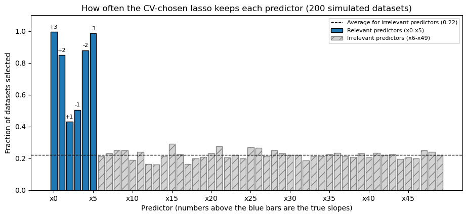

```python
sel_rate = mc_selected.mean(axis=0)
fig, ax = plt.subplots(figsize=(11, 4.5))
ax.bar(range(6), sel_rate[:6], color='tab:blue', edgecolor='black', label='Relevant predictors (x0-x5)')
ax.bar(range(6, p), sel_rate[6:], color='lightgray', edgecolor='gray', hatch='//',
       label='Irrelevant predictors (x6-x49)')
ax.axhline(sel_rate[6:].mean(), color='black', linestyle='--', linewidth=1,
           label=f'Average for irrelevant predictors ({sel_rate[6:].mean():.2f})')
for j in range(6):
    ax.text(j, sel_rate[j] + 0.02, f'{beta_true[j]:+.0f}', ha='center', fontsize=8)
ax.set_xticks(range(0, p, 5))
ax.set_xticklabels([f'x{j}' for j in range(0, p, 5)])
ax.set_ylim(0, 1.1)
ax.set_xlabel('Predictor (numbers above the blue bars are the true slopes)')
ax.set_ylabel('Fraction of datasets selected')
ax.set_title(f'How often the CV-chosen lasso keeps each predictor ({n_sims} simulated datasets)')
ax.legend(loc='upper right', fontsize=8)
plt.show()
```

The lasso almost always keeps the predictors with large true slopes ($\pm 3$) and usually keeps the medium ones ($\pm 2$). But it misses the weak predictors ($\pm 1$) about half the time, and it lets each irrelevant predictor in a fair fraction of the time. Variable selection by the lasso is helpful but far from perfect -- with noisy data, a weak but real predictor is hard to tell apart from an irrelevant one. In practice, this means we should be cautious about interpreting the particular set of predictors the lasso selects in any one sample. Its main job, and the thing it does well here, is to *predict*.

## Application: Can Regularization Rescue the Kitchen Sink?

Now back to the motivating example. We repeat the expanding-window OOS exercise on the Goyal-Welch data, with the same nine predictors, but now estimate ridge and the lasso in place of OLS. Each year, within the current estimation window, the code:

1. Standardizes the predictors, using only the data in the window (so that the penalty treats all nine predictors equally, as discussed above).
2. Chooses the penalty by 5-fold cross-validation within the window. The folds are contiguous blocks of years (`KFold` without shuffling), the compromise for time series data mentioned above.
3. Estimates the model with the chosen penalty and forecasts next year's return.

The test sample is now the sequence of OOS years, 1958-2024, and the benchmark is again the historical average. (This cell takes a minute or so to run: ridge and the lasso are each re-estimated many times for every one of the 67 forecasts.)

```python
cv5 = KFold(5)        #5 contiguous blocks of years (no shuffling)
oos_ridge = oos_forecasts(X_gw, y_gw, RidgeCV(alphas=np.logspace(-2, 5, 50), cv=cv5))
oos_lasso = oos_forecasts(X_gw, y_gw, LassoCV(cv=cv5, max_iter=50000))

oos_all = pd.DataFrame({'actual': oos_ols['actual'], 'hist_mean': oos_ols['hist_mean'],
                        'OLS': oos_ols['model'], 'Ridge': oos_ridge['model'], 'Lasso': oos_lasso['model']})
for m in ['OLS', 'Ridge', 'Lasso']:
    print(f"Out-of-sample R-squared vs. historical average, {m:>5}: {100 * r2_oos(oos_all, m):6.1f}%")
print("\nStandard deviation of the forecasts (% per year):")
print(oos_all[['hist_mean', 'OLS', 'Ridge', 'Lasso']].std().round(2).to_string())
print(f"\nLasso: average number of predictors kept = {oos_lasso['n_used'].mean():.1f} of {len(ks_predictors)}; "
      f"fraction of years with none kept = {(oos_lasso['n_used'] == 0).mean():.2f}")
```

```
Out-of-sample R-squared vs. historical average,   OLS:  -64.3%
Out-of-sample R-squared vs. historical average, Ridge:    1.6%
Out-of-sample R-squared vs. historical average, Lasso:  -13.7%

Standard deviation of the forecasts (% per year):
hist_mean     0.79
OLS          14.06
Ridge         7.23
Lasso         7.96

Lasso: average number of predictors kept = 1.4 of 9; fraction of years with none kept = 0.40
```

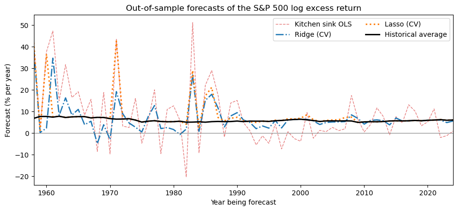

```python
fig, ax = plt.subplots(figsize=(11, 4.5))
ax.plot(oos_all.index, oos_all['OLS'], color='tab:red', linestyle='--', linewidth=1, alpha=0.6, label='Kitchen sink OLS')
ax.plot(oos_all.index, oos_all['Ridge'], color='tab:blue', linestyle='-.', linewidth=1.8, label='Ridge (CV)')
ax.plot(oos_all.index, oos_all['Lasso'], color='tab:orange', linestyle=':', linewidth=2.2, label='Lasso (CV)')
ax.plot(oos_all.index, oos_all['hist_mean'], color='black', linewidth=2, label='Historical average')
ax.axhline(0, color='gray', linewidth=0.8)
ax.set_title("Out-of-sample forecasts of the S&P 500 log excess return")
ax.set_xlabel("Year being forecast")
ax.set_ylabel("Forecast (% per year)")
ax.set_xlim(oos_all.index.min(), oos_all.index.max())
ax.legend(ncol=2)
plt.show()
```

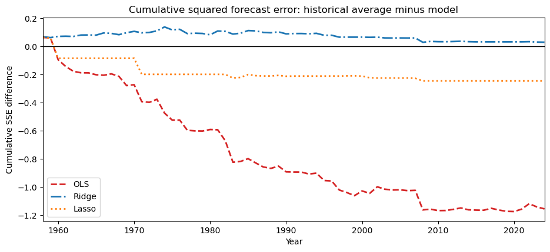

```python
fig, ax = plt.subplots(figsize=(11, 4.5))
styles = {'OLS': ('tab:red', '--'), 'Ridge': ('tab:blue', '-.'), 'Lasso': ('tab:orange', ':')}
for m, (color, ls) in styles.items():
    #Goyal-Welch plot: cumulative (historical-average squared error - model squared error), in decimals
    csum = (((oos_all['actual'] - oos_all['hist_mean']) / 100)**2
            - ((oos_all['actual'] - oos_all[m]) / 100)**2).cumsum()
    ax.plot(oos_all.index, csum, color=color, linestyle=ls, linewidth=2, label=m)
ax.axhline(0, color='black', linewidth=1)
ax.set_title("Cumulative squared forecast error: historical average minus model")
ax.set_xlabel("Year")
ax.set_ylabel("Cumulative SSE difference")
ax.set_xlim(oos_all.index.min(), oos_all.index.max())
ax.legend()
plt.show()
```

### Discussion

Regularization does much of what it was designed to do. The ridge and lasso forecasts are considerably calmer than the OLS forecasts (their standard deviations are roughly half of OLS's), and most of the kitchen sink model's large OOS losses disappear. In the Goyal-Welch plot, OLS loses ground to the historical average for decades, while ridge stays slightly ahead of it throughout and the lasso falls modestly behind.

Two features of the results are worth dwelling on.

1. **Most of the time, cross-validation chooses to shrink almost all the way to the historical average.** The lasso keeps only one or two of the nine predictors in a typical year, and none at all in roughly two years out of five. From about 1990 on, both the ridge and lasso forecasts are within a few percentage points of the historical average. With noisy annual returns, the data say that these predictors don't carry enough reliable information to justify sizable slopes.
2. **The remaining damage comes from a few early years.** Around 1960, 1971, and the mid-1980s, the ridge and lasso forecasts spike almost as much as the OLS forecasts, and essentially all of the lasso's OOS losses come from two of those episodes. Early on, the estimation window has only 30 or 40 observations, so each cross-validation fold has only 6 to 8 -- cross-validation estimates the best penalty from the data, and with this little data, that estimate is itself noisy. In those years it sometimes chose too little shrinkage.

So regularization does *not* produce a model that clearly beats the historical average. Ridge roughly breaks even, and the lasso loses a little, though both do far better than OLS.

This is an honest and important result. Regularization protects us from the *damage* that overfitting does: it is a way of using many predictors without paying the price we paid in `PredictiveRegressions.ipynb`. It cannot create predictive information that isn't in the data. Whether it pays off depends on how much signal the predictors really contain -- which is why the research since Goyal and Welch has pursued both better methods and better predictors. In settings with much more data, such as forecasting the returns of thousands of individual stocks from dozens or hundreds of firm characteristics, regularization methods have proven much more useful.

## Takeaways

- **OLS overfits when there are many predictors relative to observations.** In the simulation, OLS with 50 predictors and 100 observations had a training MSE far below the noise variance and a test MSE far above it, worse even than ignoring the predictors and using the sample mean. With more coefficients than observations, OLS has no unique solution at all.
- **Ridge and the lasso are penalized least squares.** Both add a penalty on the size of the slopes to the RSS, with a parameter $\lambda$ that moves the estimates from OLS ($\lambda = 0$) toward the sample mean ($\lambda \to \infty$). Shrinking trades a little bias for a large reduction in variance. Because the penalty depends on units, predictors should be standardized first.
- **Ridge shrinks proportionally; the lasso soft-thresholds.** With one predictor, ridge multiplies the OLS estimate by a shrinkage factor between zero and one, while the lasso subtracts a fixed amount and sets small estimates exactly to zero. So the lasso performs variable selection and produces sparse models; ridge keeps every predictor.
- **Cross-validation chooses $\lambda$ using only the training data,** by repeatedly holding out part of the training sample and choosing the penalty with the smallest average prediction error on the held-out parts. The cross-validated MSE has a U-shape with a "Goldilocks" minimum.
- **In repeated simulations, both regularized methods beat OLS and the sample mean nearly every time.** The lasso reliably kept the strong predictors, but missed weak ones about half the time and let in some irrelevant ones, so the particular set of variables it selects should be interpreted cautiously.
- **On the Goyal-Welch data, regularization rescues the kitchen sink from disaster, but does not turn it into a winner.** Ridge roughly breaks even with the historical average out of sample and the lasso loses modestly, compared with an OOS $R^2$ of around -64% for OLS. Most of the time cross-validation shrinks the forecasts nearly all the way to the historical average; the remaining losses come from a few early years, when the estimation window was short and cross-validation itself was unreliable.

**Where this goes next.** Ridge and the lasso are linear models with a penalty. The same ideas -- fit flexibly, penalize complexity, and choose the amount of penalty by cross-validation on a training sample, with performance judged on a test sample -- carry over to the nonlinear machine learning methods (regression trees, random forests, neural networks) that come next, and that have been applied to predicting the cross-section of stock returns from large numbers of firm characteristics.

## Additional Technical Material

This appendix collects the technical details behind results stated in the main text. The first subsection derives the one-predictor ridge and lasso estimates, using only algebra and a little calculus. The remaining subsections write OLS and ridge regression in matrix notation, derive the ridge estimator, and make precise the statements in the main text about why OLS fails when $p + 1 > N$ and why ridge does not.

### Ridge and lasso with a single predictor

This subsection derives the one-predictor results stated in the main text. To keep the algebra simple, suppose $X_i$ and $Y_i$ have both been de-meaned, so that we can drop the intercept. The OLS slope is then

$$ \hat{\beta}^{OLS} = \frac{\sum_i X_i Y_i}{\sum_i X_i^2}. $$

Write $S_{xx} = \sum_i X_i^2$ and $S_{xy} = \sum_i X_i Y_i$, so $\hat{\beta}^{OLS} = S_{xy} / S_{xx}$. Expanding the square, the RSS is

$$ \text{RSS}(\beta) = \sum_i (Y_i - \beta X_i)^2 = \sum_i Y_i^2 - 2\beta S_{xy} + \beta^2 S_{xx}, $$

a parabola in $\beta$ whose slope (derivative) is $-2S_{xy} + 2\beta S_{xx}$.

**Ridge.** The ridge criterion is $\text{RSS}(\beta) + \lambda\beta^2$. Setting its derivative to zero,

$$ -2S_{xy} + 2\beta S_{xx} + 2\lambda\beta = 0 \quad\Longrightarrow\quad \hat{\beta}^{R} = \frac{S_{xy}}{S_{xx} + \lambda} = \hat{\beta}^{OLS} \times \frac{S_{xx}}{S_{xx} + \lambda}. $$

Ridge multiplies the OLS estimate by a shrinkage factor between zero and one. The factor is one when $\lambda = 0$ and falls toward zero as $\lambda$ grows, but it never reaches zero for any finite $\lambda$. Ridge shrinks *proportionally*: a big OLS coefficient and a small one are shrunk by the same percentage, and neither becomes exactly zero.

**Lasso.** The lasso criterion is $\text{RSS}(\beta) + \lambda|\beta|$. The absolute value has a kink at zero, so we consider the cases $\beta > 0$ and $\beta < 0$ separately. For $\beta > 0$, $|\beta| = \beta$, and setting the derivative to zero gives

$$ -2S_{xy} + 2\beta S_{xx} + \lambda = 0 \quad\Longrightarrow\quad \beta = \hat{\beta}^{OLS} - \frac{\lambda}{2S_{xx}}, $$

which is a valid solution only if it is actually positive, i.e., if $\hat{\beta}^{OLS} > \lambda / (2S_{xx})$. Symmetrically, for $\beta < 0$, $|\beta| = -\beta$, and we get $\beta = \hat{\beta}^{OLS} + \lambda/(2S_{xx})$, valid only if $\hat{\beta}^{OLS} < -\lambda/(2S_{xx})$. What if $\hat{\beta}^{OLS}$ is between these two thresholds? Then neither case has a solution, and the minimum is at the kink, $\beta = 0$. The reason: starting from $\beta = 0$, a small move of size $\delta$ in either direction lowers the RSS at a rate of at most $2|S_{xy}|$ per unit of $\delta$ (the slope of the RSS parabola at zero), but raises the penalty at the rate $\lambda$. If $2|S_{xy}| < \lambda$ -- equivalently, $|\hat{\beta}^{OLS}| < \lambda/(2S_{xx})$ -- moving away from zero costs more than it gains. Putting the three cases together, with $c = \lambda / (2 S_{xx})$:

$$ \hat{\beta}^{L} = \begin{cases} \hat{\beta}^{OLS} - c & \text{if } \hat{\beta}^{OLS} > c \\ 0 & \text{if } |\hat{\beta}^{OLS}| \le c \\ \hat{\beta}^{OLS} + c & \text{if } \hat{\beta}^{OLS} < -c. \end{cases} $$

This is called **soft thresholding**. The lasso subtracts a fixed amount $c$ from the size of the OLS coefficient, and if the OLS coefficient is smaller than $c$ to begin with, it is set to exactly zero. Small, probably-noise coefficients are eliminated, while large coefficients survive (shrunk by $c$).

The next cell verifies these formulas numerically, using `scikit-learn`'s `Ridge` and `Lasso` estimators on a small simulated dataset with one predictor (with `fit_intercept=False`, since we de-mean the data ourselves, and converting $\lambda$ to the lasso's `alpha` as described in the main text).

```python
rng1 = np.random.default_rng(1)
n1 = 100
x1 = rng1.standard_normal(n1)
y1 = 0.5 * x1 + rng1.standard_normal(n1)
x1, y1 = x1 - x1.mean(), y1 - y1.mean()                  #de-mean, so no intercept is needed
S_xx, S_xy = np.sum(x1**2), np.sum(x1 * y1)
b_hat_ols = S_xy / S_xx
print(f"OLS slope: {b_hat_ols:.4f}\n")

print(f"{'lambda':>7} | {'ridge: formula':>14} {'sklearn':>8} | {'lasso: formula':>14} {'sklearn':>8}")
for lam in [10, 50, 100, 150]:
    ridge_formula = S_xy / (S_xx + lam)
    c = lam / (2 * S_xx)
    lasso_formula = np.sign(b_hat_ols) * max(abs(b_hat_ols) - c, 0)
    ridge_sk = Ridge(alpha=lam, fit_intercept=False).fit(x1.reshape(-1, 1), y1).coef_[0]
    lasso_sk = Lasso(alpha=lam / (2 * n1), fit_intercept=False).fit(x1.reshape(-1, 1), y1).coef_[0]
    print(f"{lam:>7} | {ridge_formula:>14.4f} {ridge_sk:>8.4f} | {lasso_formula:>14.4f} {lasso_sk:>8.4f}")
```

```
OLS slope: 0.4686

 lambda | ridge: formula  sklearn | lasso: formula  sklearn
     10 |         0.4118   0.4118 |         0.3996   0.3996
     50 |         0.2773   0.2773 |         0.1238   0.1238
    100 |         0.1970   0.1970 |         0.0000   0.0000
    150 |         0.1527   0.1527 |         0.0000   0.0000
```

The formulas match `scikit-learn` exactly. Notice how the two estimators behave as $\lambda$ rises: the ridge estimate falls gradually but stays positive, while the lasso estimate falls by a fixed amount for each increase in $\lambda$ and then hits zero once $\lambda$ is large enough.

**The rest of this appendix uses matrix and vector notation from `BasicsLinearAlgebra.ipynb`, including matrix inverses and the idea of a singular (non-invertible) matrix. It is optional and safe to skip.**

### OLS and ridge in matrix form

Stack the outcomes in an $N \times 1$ vector $Y$, and the predictors in an $N \times p$ matrix $X$ whose $(i, j)$ element is $X_{i,j}$. To keep the algebra clean, assume that $Y$ and every column of $X$ have been de-meaned, so that the intercept is zero and can be dropped (with de-meaned data the OLS and ridge intercepts are both zero, so this loses nothing). With a $p \times 1$ coefficient vector $\beta$, the RSS is

$$ \text{RSS}(\beta) = (Y - X\beta)^{\prime}(Y - X\beta) = Y^{\prime}Y - 2\beta^{\prime}X^{\prime}Y + \beta^{\prime}X^{\prime}X\beta. $$

Setting the derivative with respect to $\beta$ to zero gives the OLS normal equations $X^{\prime}X\beta = X^{\prime}Y$, and, *if $X^{\prime}X$ is invertible*,

$$ \hat{\beta}^{OLS} = (X^{\prime}X)^{-1}X^{\prime}Y. $$

### Why OLS fails when $p \ge N$

$X^{\prime}X$ is a $p \times p$ matrix, but its rank can be no larger than the rank of $X$, which is at most $\min(N, p)$. (With de-meaned data, which uses up one degree of freedom, the bound is actually $N - 1$; this is the matrix version of the "$p + 1 > N$" condition in the main text.) If $p$ exceeds this, $X^{\prime}X$ is singular and has no inverse. Then the normal equations have infinitely many solutions: if $X v = 0$ for some nonzero vector $v$ (which must exist when the columns of $X$ outnumber its rank), then $\beta + v$ has exactly the same fitted values, and so the same RSS, as $\beta$. Even when $X^{\prime}X$ is technically invertible, if $p$ is close to $N$ it is *nearly* singular, and its inverse has very large elements. That is the matrix version of the noisy, overfit estimates in the main text.

### The ridge estimator

The ridge criterion is $\text{RSS}(\beta) + \lambda \beta^{\prime}\beta$. Its derivative with respect to $\beta$ is $-2X^{\prime}Y + 2X^{\prime}X\beta + 2\lambda\beta$, and setting it to zero gives $(X^{\prime}X + \lambda I)\beta = X^{\prime}Y$, where $I$ is the $p \times p$ identity matrix. So

$$ \hat{\beta}^{R} = (X^{\prime}X + \lambda I)^{-1}X^{\prime}Y. $$

With one predictor, $X^{\prime}X = S_{xx}$ and $X^{\prime}Y = S_{xy}$, and this is the formula $S_{xy}/(S_{xx} + \lambda)$ from the first subsection of this appendix.

Unlike $X^{\prime}X$, the matrix $X^{\prime}X + \lambda I$ is **always invertible** when $\lambda > 0$, no matter how large $p$ is. To see why, take any nonzero $p \times 1$ vector $v$. Then

$$ v^{\prime}(X^{\prime}X + \lambda I)v = (Xv)^{\prime}(Xv) + \lambda v^{\prime}v = \sum_i (Xv)_i^2 + \lambda\sum_j v_j^2 > 0, $$

because the first sum is non-negative and the second is strictly positive. If $X^{\prime}X + \lambda I$ were singular, there would be a nonzero $v$ with $(X^{\prime}X + \lambda I)v = 0$, which would make this expression zero -- a contradiction. Adding $\lambda$ to each diagonal element of $X^{\prime}X$ is what gives ridge regression its name: it adds a "ridge" along the diagonal that makes the matrix well behaved. So ridge regression has a unique solution even with more predictors than observations. (The lasso has no closed-form solution, because the absolute value is not differentiable at zero; it is computed by numerical optimization.)

### Numerical check

The next cell checks that the matrix formula reproduces `scikit-learn`'s ridge estimates on the simulated training data, and that it still works in a case with more predictors than observations, where $X^{\prime}X$ is singular and OLS has no unique solution.

```python
#De-mean the training data, then apply the ridge formula and compare with scikit-learn
Xd = (X_train - X_train.mean()).values
Yd = (Y_train - Y_train.mean()).values
lam = 50
beta_formula = np.linalg.solve(Xd.T @ Xd + lam * np.eye(p), Xd.T @ Yd)
beta_sklearn = Ridge(alpha=lam).fit(X_train, Y_train).coef_
print(f"Largest difference between formula and scikit-learn ridge slopes: {np.abs(beta_formula - beta_sklearn).max():.2e}")

#Now use only the first 40 training observations: p = 50 > N = 40
Xs, Ys = Xd[:40] - Xd[:40].mean(axis=0), Yd[:40] - Yd[:40].mean()
print(f"\nWith N = 40 and p = {p}: rank of X'X = {np.linalg.matrix_rank(Xs.T @ Xs)} (out of {p}), "
      f"so X'X is singular and OLS has no unique solution")
print(f"Rank of X'X + lambda*I = {np.linalg.matrix_rank(Xs.T @ Xs + lam * np.eye(p))} (out of {p}), "
      f"so the ridge estimate is unique")
beta40 = np.linalg.solve(Xs.T @ Xs + lam * np.eye(p), Xs.T @ Ys)
beta40_sklearn = Ridge(alpha=lam).fit(X_train.iloc[:40], Y_train.iloc[:40]).coef_
print(f"Largest difference between formula and scikit-learn with N = 40: {np.abs(beta40 - beta40_sklearn).max():.2e}")
```

```
Largest difference between formula and scikit-learn ridge slopes: 6.66e-16

With N = 40 and p = 50: rank of X'X = 39 (out of 50), so X'X is singular and OLS has no unique solution
Rank of X'X + lambda*I = 50 (out of 50), so the ridge estimate is unique
Largest difference between formula and scikit-learn with N = 40: 1.11e-15
```